# Machine Learning Assignment

Rob Hurst

27 July 2016

Background

Using devices such as Jawbone Up, Nike FuelBand, and Fitbit it is now possible to collect a large amount of data about personal activity relatively inexpensively. These type of devices are part of the quantified self movement – a group of enthusiasts who take measurements about themselves regularly to improve their health, to find patterns in their behavior, or because they are tech geeks. One thing that people regularly do is quantify how much of a particular activity they do, but they rarely quantify how well they do it. In this project, your goal will be to use data from accelerometers on the belt, forearm, arm, and dumbell of 6 participants. They were asked to perform barbell lifts correctly and incorrectly in 5 different ways. More information is available from the website here: http://groupware.les.inf.puc-rio.br/har (see the section on the Weight Lifting Exercise Dataset).

```r
# Libraries
library(caret)
```

```r
library(rpart)
library(rpart.plot)
library(RColorBrewer)
library(randomForest)
library(RCurl)
```

Get the data

```r
setwd("/Users/robhurst/MachineLearning")

trainUrl <- "http://d396qusza40orc.cloudfront.net/predmachlearn/pml-training.csv"
testUrl <- "http://d396qusza40orc.cloudfront.net/predmachlearn/pml-testing.csv"


trainingOrg <- read.csv(url(trainUrl), na.strings=c("NA","#DIV/0!",""))
testingOrg = read.csv(url(testUrl), na.strings=c("", "NA", "NULL"))

dim(trainingOrg)
```

```
## [1] 19622   160
```

```r
# Remove columns with too many NAs

missingData <-  is.na(trainingOrg)
omitColumns = which(colSums(missingData) > 1000)
trainingOrg <- trainingOrg[,-omitColumns]
dim(trainingOrg)
```

```
## [1] 19622    60
```

Create Test and Train Samples. Set the seed for the sake of reproducability.

```r
set.seed(1234)
inTrain <- createDataPartition(y=trainingOrg$classe, p=0.6, list=FALSE)
myTraining <- trainingOrg[inTrain, ]; myTesting <- trainingOrg[-inTrain, ]
dim(myTraining); dim(myTesting)
```

```
## [1] 11776    60
```

```
## [1] 7846   60
```

```r
time1 = proc.time()
(randForest = randomForest(classe~., data=myTraining, ntree = 500))
```

```
##
## Call:
##  randomForest(formula = classe ~ ., data = myTraining, ntree = 500)
##                Type of random forest: classification
##                      Number of trees: 500
## No. of variables tried at each split: 7
##
##         OOB estimate of  error rate: 0.02%
## Confusion matrix:
##      A    B    C    D    E  class.error
## A 3348    0    0    0    0 0.0000000000
## B    1 2278    0    0    0 0.0004387889
## C    0    1 2053    0    0 0.0004868549
## D    0    0    0 1930    0 0.0000000000
## E    0    0    0    0 2165 0.0000000000
```

Applying the Model to the Testing Subsample. After training the predictor we use it on the testing subsample we constructed before, to get an estimate of its out of sample error.

```r
predictionTesting = predict(randForest, newdata = myTesting)
```

The error estimate can be obtained with the confusionMatrix function of the caret package:

```r
confusionMatrix(predictionTesting, myTesting$classe)
```

```
## Confusion Matrix and Statistics
##
##           Reference
## Prediction    A    B    C    D    E
##          A 2232    1    0    0    0
##          B    0 1517    0    0    0
##          C    0    0 1368    0    0
##          D    0    0    0 1286    0
##          E    0    0    0    0 1442
##
## Overall Statistics
##
##                Accuracy : 0.9999
##                  95% CI : (0.9993, 1)
##     No Information Rate : 0.2845
##     P-Value [Acc > NIR] : < 2.2e-16
##
##                   Kappa : 0.9998
##  Mcnemar's Test P-Value : NA
##
## Statistics by Class:
##
##                      Class: A Class: B Class: C Class: D Class: E
## Sensitivity            1.0000   0.9993   1.0000   1.0000   1.0000
## Specificity            0.9998   1.0000   1.0000   1.0000   1.0000
## Pos Pred Value         0.9996   1.0000   1.0000   1.0000   1.0000
## Neg Pred Value         1.0000   0.9998   1.0000   1.0000   1.0000
## Prevalence             0.2845   0.1935   0.1744   0.1639   0.1838
## Detection Rate         0.2845   0.1933   0.1744   0.1639   0.1838
## Detection Prevalence   0.2846   0.1933   0.1744   0.1639   0.1838
## Balanced Accuracy      0.9999   0.9997   1.0000   1.0000   1.0000
```

Graph the impact of the top features

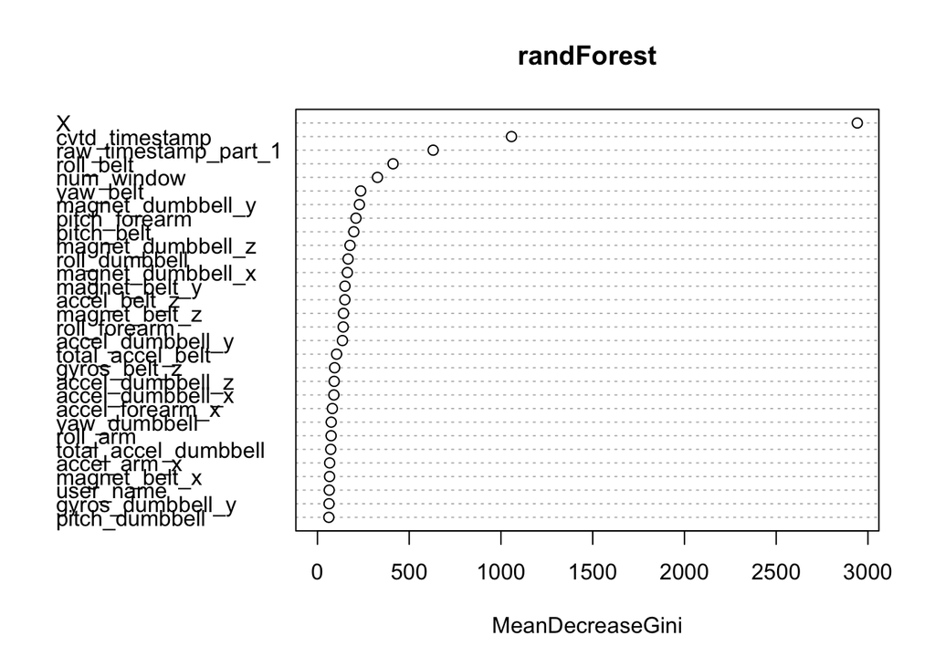

```r
varImpPlot(randForest)
```